# Tollefson April 2021

# 4 Farmland conversion and urban expansion: 1990 to 2017

I rely on two datasets to measure the spatial structure of urban expansion and farmland conversion at the county level. Urban expansion is measured by the total number of new residential building permits authorized between 1997 and 2017; each year of building permit data is scaled according to that year’s county-wide population estimate. Farm conversion is measured by the change in the number of total acres in active agricultural production over the same period, scaled according to total land area. I avoid proportional measures of farmland conversion because I am interested in the spatial extent of former farm acreage: A significant percent-wise decrease in farmland in a county with minimal agricultural production is not a meaningful measure of large-scale landscape change.

Together, these two measured allow us to identify counties with a large amount of new residential construction as well as a significant loss in farm acreage. To scale upward from county-wide to regional measures, I calculate the Getis-Ord Gi-star statistic for each county in both datasets. The Gi-star statistic produces an estimate of the difference between counties and their immediate neighbors, taking into account the spatial structure of the underlying data. This allows us to identify contiguous regions that represent local maxima for the urban development and farmland variables calculated above.

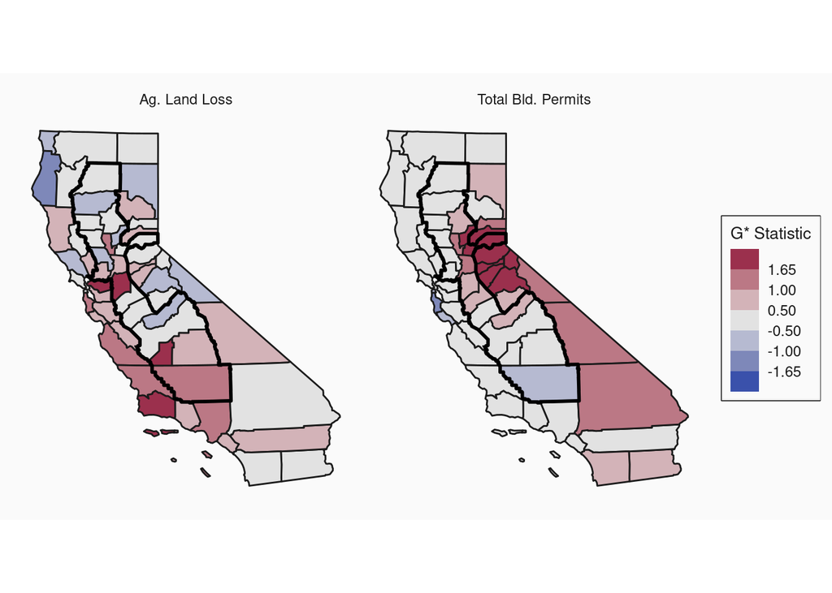

Figure 4.1: Getis-Ord G* statistics. Left panel: Loss in total farmland, scaled to total county size, 1997 to 2017. Right panel: Total building permits, scaled to county-wide population, 1997 to 2017.

Figure 4.1 displays the output of the Gi-star calculation. The Gi-star statistic follows a standard Z-distribution: Counties greater than 1.65 on the Gi-star measure have urban expansion or farmland conversion results that are significantly higher than their neighbors at the (P < 0.05) level, while counties less than -1.65 on the Gi-star measures are significantly lower. Two patterns stand out above. First, we can identify a large contiguous region of new residential construction in the northern half of the Central Valley. While Sacramento and Yuba Counties, outlined in black, have experienced a large influx of new residents, building permit data doesn’t directly follow recent trends in population growth, which has additionally clustered around the San Francisco Bay Area and in the outlying counties surrounding Los Angeles. Agricultural land loss, meanwhile, is more spatially distributed, with several hot-spots along the south-central coast and in San Joaquin and Kings Counties in the mid-reaches of the Central Valley.

The Central Valley region is also easily identified by mapping agricultural pesticide application. See Figure 4.2, which displays the intensity of 27 years of pesticide application data for each California county, measured by total county land-area, as well as a similar measure of change in yearly pesticide totals between 1990 and 2017. Here, Central Valley counties - notably San Joaquin, the source for Larsen et al’s (2017) pesticide health data - are joined by the wine-growing regions immediately north of the San Francisco Bay area. EPA toxicity categories 3 and 4 are extracted from the full set of EPA-registered chemicals and displayed on the right-hand panel. The lower half displays the proportional change in pesticide application rates over the 27-year span of available data. Agricultural pesticide use has also generally increased over the last thirty years: Central Valley counties applied between 0.5 and 1.3 additional pounds of active ingredient per 1,000 acres of land-area in 2017 compared to 1990. In Tulare County, for instance, an 0.8 pounds-per-thousand-acres increase translated to a 10-fold increase in category 3 and 4 application rates over that period.

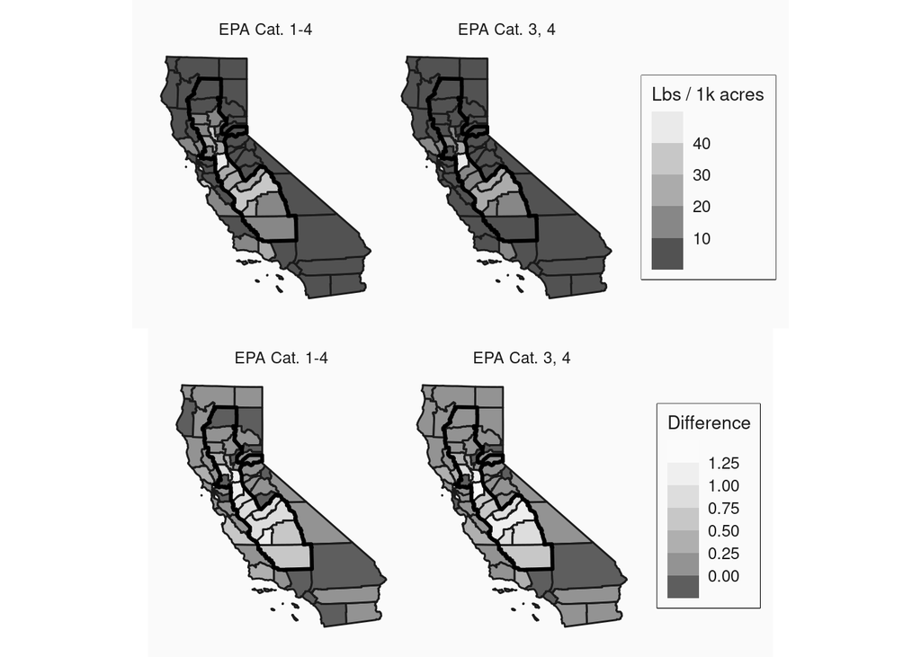

Figure 4.2: EPA-registered pesticide application. Left panels display all EPA toxicity levels. Right panels display EPA toxicity codes 3 and 4 only. Upper panels display total application in pounds of active igredient per 1000 acres. Lower panels display the difference in pounds of active ingredient applied per 1000 acres between 1990 and 2017. San Francisco County is an outlier at 94 pounds per thousand acres, total 1990-2017, due to its small land area and high volume of landscaping applications.

# 5 Technoregions and chemospheres

# 6 Sacramento

Recent new residential construction in Sacramento

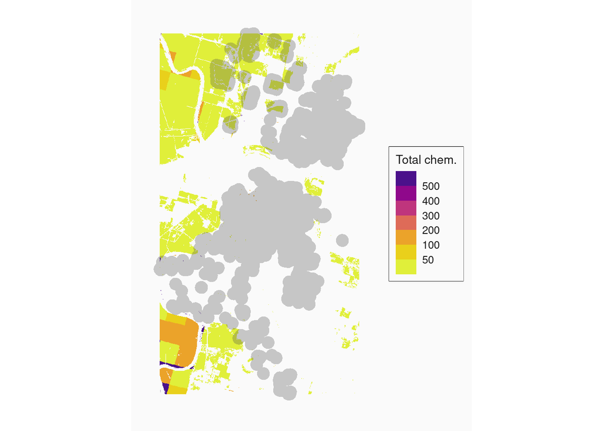

Figure 6.1: Total pesticide application estimates and new residential construction. Gray overlay shows 500-meter radius around all parcels with new residential construction between 2012 and 2020.

# 7 Stockton

# 8 Freso

# 9 Multi-level random effects

# 10 Conclusion

## 10.1 Further research

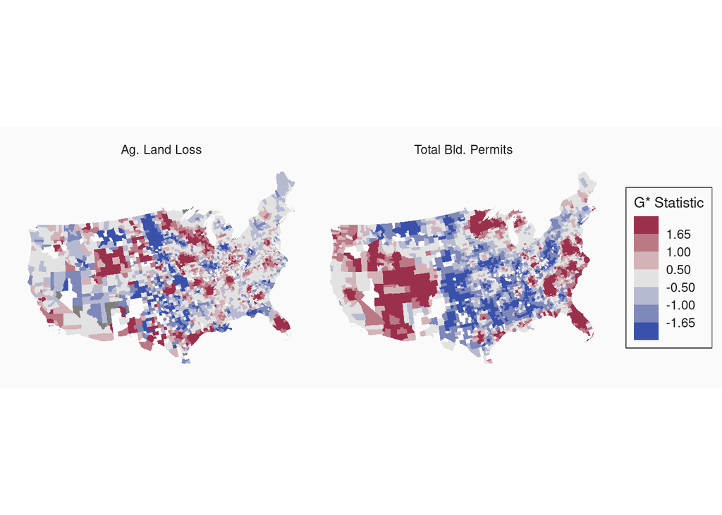

Figure 10.1: Getis-Ord G* statistics. Left panel: Loss in total farmland, scaled to total county size, 1997 to 2017. Right panel: Total building permits, scaled to county-wide population, 1997 to 2017.

# References

Agyeman, J., Schlosberg, D., Craven, L., & Matthews, C. (2016). Trends and directions in environmental justice: From inequity to everyday life, community, and just sustainabilities. *Annual Review of Environment and Resources*, *41*(1), 321–340. https://doi.org/10.1146/annurev-environ-110615-090052

Arora, S., & Cason, T. N. (1999). Do community characteristics influence environmental outcomes? Evidence from the toxics release inventory. *Southern Economic Journal*, *65*(4), 691–716. https://doi.org/10.2307/1061271

Brody, J. G., Vorhees, D. J., Melly, S. J., Swedis, S. R., Drivas, P. J., & Rudel, R. A. (2002). Using GIS and historical records to reconstruct residential exposure to large-scale pesticide application. *Journal of Exposure Science & Environmental Epidemiology*, *12*(1), 64–80.

Brody, J. G., Vorhees, D. J., Melly, S. J., Swedis, S. R., Drivas, P. J., & Rudel, R. A. (2002). Using GIS and historical records to reconstruct residential exposure to large-scale pesticide application. *Journal of Exposure Science & Environmental Epidemiology*, *12*(1), 64–80.

Bullard, R., Johnson, G. S., & Torres, A. O. (2000). *Sprawl city: Race, politics, and planning in Atlanta*. Island Press.

Conley, D. (2001). Decomposing the black-white wealth gap: The role of parental resources, inheritance, and investment dynamics. *Sociological Inquiry*, *71*(1), 39–66. https://doi.org/10.1111/j.1475-682X.2001.tb00927.x

Crowder, K., & Downey, L. (2010). Inter-neighborhood migration, race, and environmental hazards: Modeling microlevel processes of environmental inequality. *American Journal of Sociology*, *115*(4), 1110–1149. https://doi.org/10.1086/649576

Dietzel, C., Herold, M., Hemphill, J. J., & Clarke, K. C. (2005). Spatio‐temporal dynamics in California’s Central Valley: Empirical links to urban theory. *International Journal of Geographical Information Science*, *19*(2), 175–195. https://doi.org/10.1080/13658810410001713407

Downey, L. (2006). Environmental racial inequality in detroit. *Social Forces*, *85*(2), 771–796. https://doi.org/10.1353/sof.2007.0003

Downey, Liam. (2005). The unintended significance of race: Environmental racial inequality in Detroit. *Social Forces*, *83*(3), 971–1007.

Dugoua, E., Kennedy, R., & Urpelainen, J. (2018). Satellite data for the social sciences: Measuring rural electrification with night-time lights. *International Journal of Remote Sensing*, *39*(9), 2690–2701. https://doi.org/10.1080/01431161.2017.1420936

Frickel, S., & Elliott, J. R. (2018). *Sites unseen: Uncovering hidden hazards in American cities*. Russel Sage Foundation.

Hannigan, J., & Richards, G. (2017). *The SAGE handbook of new urban studies*. Sage.

Hawley, A. H. (1986). *Human ecology: A theoretical essay*. University of Chicago Press.

Larsen, A. E., Gaines, S. D., & Deschênes, O. (2017). Agricultural pesticide use and adverse birth outcomes in the San Joaquin Valley of California. *Nature Communications*, *8*(1), 302. https://doi.org/10.1038/s41467-017-00349-2

LeRoy, S. F., & Sonstelie, J. (1983). Paradise lost and regained: Transportation innovation, income, and residential location. *Journal of Urban Economics*, *13*(1), 67–89. https://doi.org/10.1016/0094-1190(83)90046-3

Manduca, R., & Sampson, R. J. (2019). Punishing and toxic neighborhood environments independently predict the intergenerational social mobility of black and white children. *Proceedings of the National Academy of Sciences*, *116*(16), 7772–7777. https://doi.org/10.1073/pnas.1820464116

Marlow, T., Frickel, S., & Elliott, J. R. (2020). Do legacy industrial sites produce legacy effects in ethnic and racial residential settlement? Environmental inequality formation in Rhode Island’s industrial core. *Sociological Forum*.

Massey, D. S., & Tannen, J. (2018). Suburbanization and segregation in the United States: 1970–2010. *Ethnic and Racial Studies*, *41*(9), 1594–1611. https://doi.org/10.1080/01419870.2017.1312010

Mieszkowski, P., & Mills, E. S. (1993). The causes of metropolitan suburbanization. *Journal of Economic Perspectives*, *7*(3), 135–147. https://doi.org/10.1257/jep.7.3.135

Mohai, P., Pellow, D., & Roberts, J. T. (2009). Environmental justice. *Annual Review of Environment and Resources*, *34*, 405–430. https://doi.org/10.1146/annurev-environ-082508-094348

Mohai, P., & Saha, R. (2015). Which came first, people or pollution? Assessing the disparate siting and post-siting demographic change hypotheses of environmental injustice. *Environmental Research Letters*, *10*(11).

Paulsen, K. (2012). Yet even more evidence on the spatial size of cities: Urban spatial expansion in the US, 1980–2000. *Regional Science and Urban Economics*, *42*(4), 561–568. https://doi.org/10.1016/j.regsciurbeco.2012.02.002

Pellow, D. N. (2017). *What is critical environmental justice?* John Wiley & Sons, Ltd.

Rudel, T. K. (2009). How Do People Transform Landscapes? A Sociological Perspective on Suburban Sprawl and Tropical Deforestation. *American Journal of Sociology*, *115*(1), 129–154. https://doi.org/10.1086/597794

Van der Waal, J. (2010). *Unravelling the global city debate: Economic inequality and ethnocentrism in contemporary Dutch cities* [PhD Dissertation]. Erasmus University.

Ward, M. H., Lubin, J., Giglierano, J., Colt, J. S., Wolter, C., Bekiroglu, N., Camann, D., Hartge, P., & Nuckols, J. R. (2006). Proximity to crops and residential exposure to agricultural herbicides in Iowa. *Environmental Health Perspectives*, *114*(6), 893–897.